# Proof of concept: filtering pipeline (Clustering quality)

Paul Deveau

2016-08-19

# Creating data

This script is to show the importance of clustering high confidence variants and then attribute meaningful ones to the identified clusters

*All functions are stored inside the reproduce_2.R, to avoid long display of codes. Below are the values that will be used throughout the testing*

```r
number_iterations <- 10
number_mutations <- 200
ndrivers <- 20
```

We will first create a test set with `QuantumCat` with 6 clones, 200 variants, diploid, with an average depth of 100X, two samples with respective purity 70% and 60%. We make sure these variants correspond to stringent filters (i.e. depth $> 50$X).

```r
toy.data<-QuantumCat_stringent(number_of_clones = 6,number_of_mutations = number_mutations,
                     ploidy = "AB",depth = 100,
                     contamination = c(0.3,0.4),min_depth = 50)
```

We check that all these variants are within the stringent filters (i.e depth $\geq 50$ X), and display the first six rows of the first sample:

```r
sum(toy.data[[1]]$Depth<50 | toy.data[[2]]$Depth<50)
```

```
## [1] 0
```

```r
kable(toy.data[[1]][1:6,])
```

| Chr | Start | Genotype | Cellularit | number_of_copies | Frequency | Depth | Alt |
| --- | --- | --- | --- | --- | --- | --- | --- |
| 1 | 1 | AB | 100 | 1 | 35.00 | 110 | 45 |
| 6 | 2 | AB | 23 | 1 | 8.05 | 223 | 17 |
| 2 | 3 | AB | 29 | 1 | 10.15 | 106 | 12 |
| 1 | 4 | AB | 100 | 1 | 35.00 | 135 | 48 |
| 2 | 5 | AB | 29 | 1 | 10.15 | 76 | 5 |
| 6 | 6 | AB | 23 | 1 | 8.05 | 137 | 14 |

Then we create 200 mutations that are in permissive filters. For that we take 50 mutations with 30 to 50 depth, 100 that have a depth $\geq 30$ in triploid (AAB) loci and 50 that have a depth $\geq 30$ in a tetraploid (AABB) locus.

```r
permissive<-QuantumCat_permissive(fromQuantumCat = toy.data ,number_of_mutations = number_mutations,
                               ploidy = "AB",depth = 100,
                               contamination = c(0.3,0.4),max_depth = 50, min_depth = 30)
kable(permissive[[1]][1:6,])
```

| Chr | Start | Cellularit | Genotype | number_of_copies | Depth | Frequency | Alt |
| --- | --- | --- | --- | --- | --- | --- | --- |
| 5 | 201 | 18 | AB | 1 | 47 | 6.30 | 2 |
| 6 | 202 | 23 | AB | 1 | 50 | 8.05 | 4 |
| 1 | 203 | 100 | AB | 1 | 41 | 35.00 | 9 |
| 6 | 204 | 23 | AB | 1 | 50 | 8.05 | 2 |
| 3 | 205 | 26 | AB | 1 | 39 | 9.10 | 3 |
| 1 | 206 | 100 | AB | 1 | 38 | 35.00 | 13 |

We are now going to select 20 drivers, with probability $3/4$ of being in the permissive filters.

```r
drivers_id<-sample(1:(2*number_mutations),size = ndrivers,prob = rep(c(1/{4*number_mutations},
                                                                       3/{4*number_mutations}),
                                                                     each = number_mutations)
                   )
drivers_id<-drivers_id[order(drivers_id)]
drivers_id
```

```
##  [1]  75 111 134 137 193 199 221 243 247 257 282 301 321 332 368 369 371
## [18] 377 378 389
```

We now want to cluster mutations using only the filtered mutations (Paper pipeline), the filtered and drivers (extended), or all mutations alltogether (All), and compare the clustering quality of these different methods.

```r
pap<-paper_pipeline(filtered = toy.data,
                    permissive = permissive,
                    drivers_id = drivers_id)

ext<-extended(filtered = toy.data,
              permissive = permissive,
              drivers_id = drivers_id)

all<-All(filtered = toy.data,
         permissive = permissive,
         drivers_id = drivers_id
)
```

We are now going to compare the quality of clustering using the Normalized Mutual Information, the number of clusters found (the truth being 6), the maximal and average error in the distance of a driver to its real position.

```r
Quality<-compare_qual(paper = pap,
                      extended = ext,
                      all = all,
                      drivers_id = drivers_id)

kable(Quality)
```

| Pipeline | NMI | Max.Distance.to.clone | nclusters | max.driv.error | mean.driv.error |
| --- | --- | --- | --- | --- | --- |
| paper | 0.6825503 | 0.2039869 | 10 | 0.7547473 | 0.2476526 |
| extended | 0.6037158 | 0.2065852 | 10 | 0.7501366 | 0.2527198 |
| all | 0.4034749 | 0.2598834 | 8 | 0.7299623 | 0.2213458 |

We are now going to reproduce this test 9 times.

```r
Quality<-rbind(Quality,
               reproduce(number_iterations-1,
                         number_mutations,
                         ndrivers)
               )

kable(Quality)
```

| Pipeline | NMI | Max.Distance.to.clone | nclusters | max.driv.error | mean.driv.error |
| --- | --- | --- | --- | --- | --- |
| paper | 0.6825503 | 0.2039869 | 10 | 0.7547473 | 0.2476526 |
| extended | 0.6037158 | 0.2065852 | 10 | 0.7501366 | 0.2527198 |
| all | 0.4034749 | 0.2598834 | 8 | 0.7299623 | 0.2213458 |
| paper | 0.7155102 | 0.1074815 | 6 | 0.8817474 | 0.2710095 |
| extended | 0.6340957 | 0.4030993 | 9 | 0.7896860 | 0.2647290 |
| all | 0.4936890 | 0.4153754 | 7 | 1.0412438 | 0.2257568 |
| paper | 0.8423360 | 0.2384540 | 8 | 0.7800641 | 0.3580381 |
| extended | 0.6981766 | 0.4103061 | 10 | 0.7800641 | 0.3225932 |
| all | 0.5536825 | 0.2478785 | 8 | 0.7800317 | 0.3030530 |
| paper | 0.5827863 | 0.4574290 | 8 | 0.7707554 | 0.1371375 |
| extended | 0.5812610 | 0.1498032 | 7 | 0.7601634 | 0.1466192 |
| all | 0.4552882 | 0.1807468 | 9 | 0.7362344 | 0.1446680 |
| paper | 0.6903397 | 0.0526058 | 9 | 1.0763624 | 0.2607857 |
| extended | 0.6739554 | 0.0346694 | 8 | 1.0791279 | 0.2556908 |
| all | 0.4895646 | 0.0614930 | 6 | 1.0835843 | 0.2703925 |
| paper | 0.7379501 | 0.2304571 | 10 | 1.1068638 | 0.3564135 |
| extended | 0.7308471 | 0.4784781 | 10 | 0.9126308 | 0.2609237 |
| all | 0.4921470 | 0.3905081 | 10 | 0.9437567 | 0.2421252 |
| paper | 0.8262385 | 0.2923164 | 9 | 0.9734792 | 0.2175008 |
| extended | 0.7262228 | 0.1985473 | 10 | 1.0748599 | 0.2742573 |
| all | 0.5468880 | 0.4551261 | 10 | 0.8296879 | 0.2727820 |
| paper | 0.6261712 | 0.2841194 | 10 | 1.0208915 | 0.2639760 |
| extended | 0.5997791 | 0.2872804 | 10 | 1.0226487 | 0.2546781 |
| all | 0.3665078 | 0.3227650 | 9 | 0.9801065 | 0.2601864 |
| paper | 0.7291911 | 0.2231600 | 6 | 0.5464281 | 0.1152165 |
| extended | 0.6751326 | 0.2338706 | 9 | 0.5381203 | 0.1138815 |
| all | 0.5009749 | 0.2278828 | 7 | 0.5498314 | 0.1369620 |
| paper | 0.6747717 | 0.2116375 | 10 | 0.5700877 | 0.1535861 |
| extended | 0.6608450 | 0.2853884 | 9 | 0.5700877 | 0.1674842 |
| all | 0.5126125 | 0.2491104 | 7 | 0.5700877 | 0.1867882 |

We can plot these results:

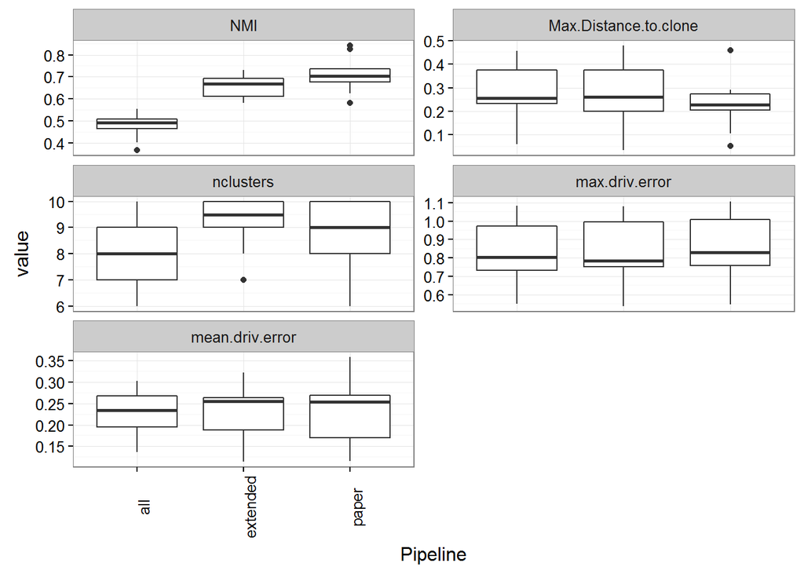